# ALRA-analysis

Jacopo Umberto Verga

2023-04-19

# ALRA interactions

I run ALRA using all the BM atlas with NK cells divided in exhausted and resident. The results are:

```r
library(tidyverse)
library(VennDiagram)
library(stringr)
all_interactions <- read_csv("all_interactions_defaults.csv", col_types = cols(...1 = col_skip()))

cat("Total number of interactions: ",dim(all_interactions)[1],"\nUnique Ligands: ",length(unique(sort(all_interactions$ligand.complex))),"\nUnique Receptors: ",length(unique(sort(all_interactions$receptor.complex))))
```

```
## Total number of interactions:  21594
## Unique Ligands:  274
## Unique Receptors:  260
```

Focusing on NK cells we have:

```
## Exhausted cells:
## Total number of interactions:  1288
## Unique Ligands:  120
## Unique Receptors:  81
```

```
## Resident cells:
## Total number of interactions:  1110
## Unique Ligands:  100
## Unique Receptors:  77
```

## Ligands

Let’s check if the lists of ligands are similar or not:

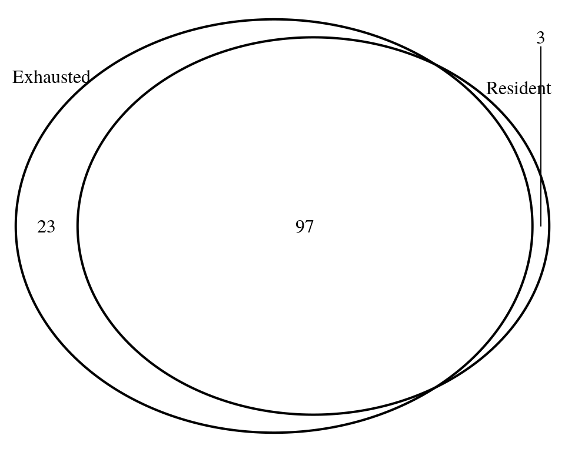

```r
exh_uniq = unique(sort(exh$ligand.complex))
res_uniq = unique(sort(res$ligand.complex))

grid.newpage()
venn_object <- venn.diagram(
        x = list(exh_uniq, res_uniq),
        category.names = c("Exhausted", "Resident"),
        filename = NULL
        )
grid.draw(venn_object)
```

Most of the ligands are shared by the 2 cell types

```r
cat("Unique ligands for NK exhausted:\n", setdiff(exh_uniq,res_uniq), "\nUnique ligands for NK resident:\n", setdiff(res_uniq,exh_uniq))
```

```
## Unique ligands for NK exhausted:
##  ARF6 ASIP CEACAM1 FASLG FN1 HGF HLA-DPA1 HLA-DPB1 HLA-DQA1 HLA-DQA2 HLA-DQB1 HLA-DRA HLA-DRB1 HLA-DRB5 LGALS3 LGALS3BP NECTIN2 NID1 NRG1 SNCA SPTAN1 TNF VSTM1
## Unique ligands for NK resident:
##  AGTRAP F11R LILRB4
```

### Exhausted:

- [ARF6](https://www.sciencedirect.com/science/article/pii/S0006497120532825) responds to FCG3A activation
- [CEACAM1](https://pubmed.ncbi.nlm.nih.gov/23696226/) Impair NK citolytic activity
- [FASLG](https://doi.org/10.3389/fimmu.2022.896228) Induce apoptosis, the source of the interaction is NK exhausted as well:

```r
exh[exh$ligand.complex == "FASLG",][,1:4]
```

```
## # A tibble: 1 × 4
##   source       target       ligand.complex receptor.complex
##   <chr>        <chr>        <chr>          <chr>
## 1 NK exhausted NK exhausted FASLG          TNFRSF1A
```

- HLA- interacts all with LAG3
- LGALS3 binds LAG3 and [inhibits NK cells](https://pubmed.ncbi.nlm.nih.gov/25315772/)
- NECTIN2 TIGIT ligand (from Megakaryocyte progenitors)
- [NRG1](https://doi.org/10.1038/s41590-022-01394-w) destabilize immunological synapse
- TNF inflammatory cytokine

### Resident

- LILRB4 [binds LAIR1 that is an inhibitory reeptor](https://www.genecards.org/cgi-bin/carddisp.pl?gene=LAIR1)

## Receptors

Let’s check if the lists of receptors are similar or not:

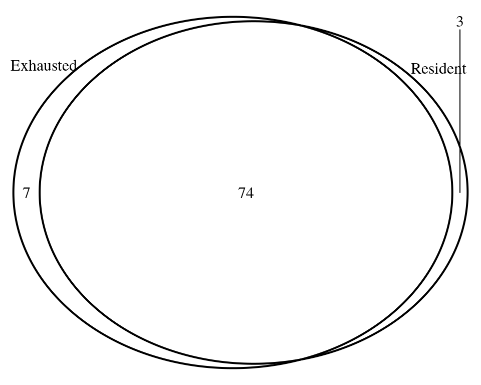

```r
exh_rec = unique(sort(exh$receptor.complex))
res_rec = unique(sort(res$receptor.complex))

grid.newpage()
venn_object <- venn.diagram(
        x = list(exh_rec, res_rec),
        category.names = c("Exhausted", "Resident"),
        filename = NULL
        )
grid.draw(venn_object)
```

Most of the receptors are shared by the 2 cell types

```r
cat("Unique receptors for NK exhausted:\n", setdiff(exh_rec,res_rec), "\nUnique receptors for NK resident:\n", setdiff(res_rec,exh_rec))
```

```
## Unique receptors for NK exhausted:
##  FAS LAG3 LAMP1 LILRB1 MGRN1 SMAP1 TIGIT
## Unique receptors for NK resident:
##  KIR2DL1 LAIR1 RACK1
```

### Exhausted

- LAG3 Immune checkpoint receptor
- TIGIT Immune checkpoint receptor
- LILRB1 reduce immune response

### Resident

-[KIR2DL1](https://pubmed.ncbi.nlm.nih.gov/27732638/) inhibitory receptor - [LAIR1 that is an inhibitory receptor](https://www.genecards.org/cgi-bin/carddisp.pl?gene=LAIR1)

## Number of interacting cells

Evaluate the proportion of celltypes that interacts with our NK cells:

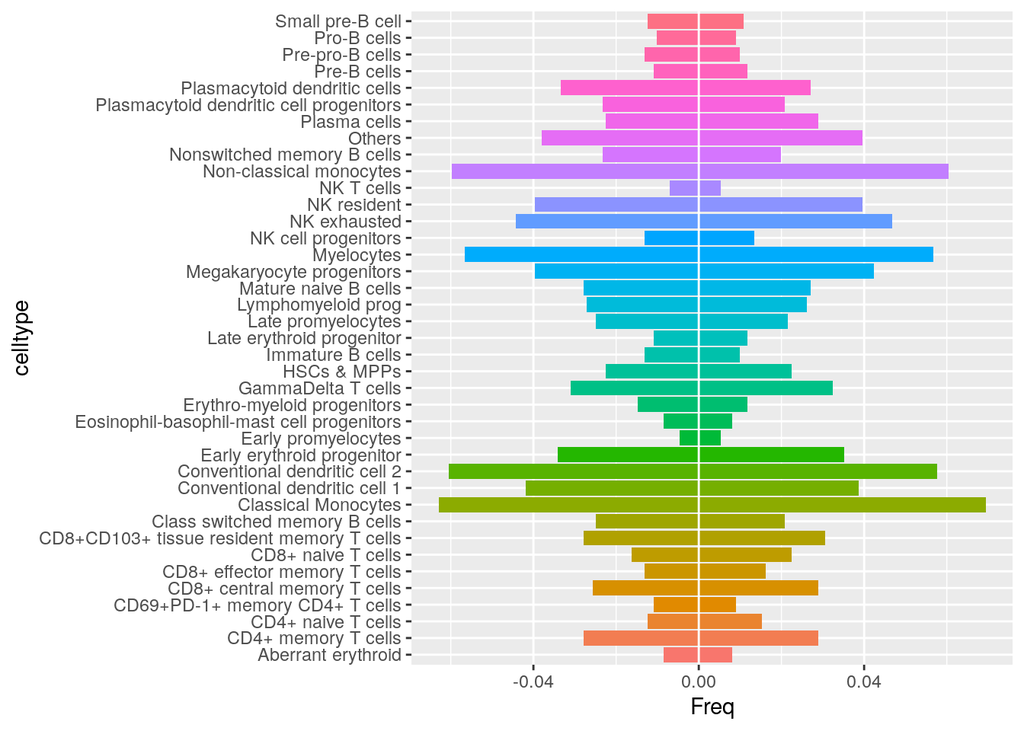

```r
exh_source <- as.data.frame(table(exh$source)/sum(table(exh$source))) %>%
  rename(celltype = "Var1") %>%
  mutate(condition="exh")
res_source <- as.data.frame(table(res$source)/sum(table(res$source))) %>%
  rename(celltype = "Var1") %>%
  mutate(condition="res")

source <- rbind(res_source,exh_source)

source_plot <- source %>%
  mutate(
    Freq = ifelse(condition=="exh", Freq*(-1),
                        Freq*1))%>%
    ggplot(aes(x = celltype,y = Freq, fill=celltype)) +
    geom_bar(stat = "identity") +
    coord_flip() +
  geom_hline(yintercept = 0, color="white")+
  theme(legend.position = "none")

source_plot
```

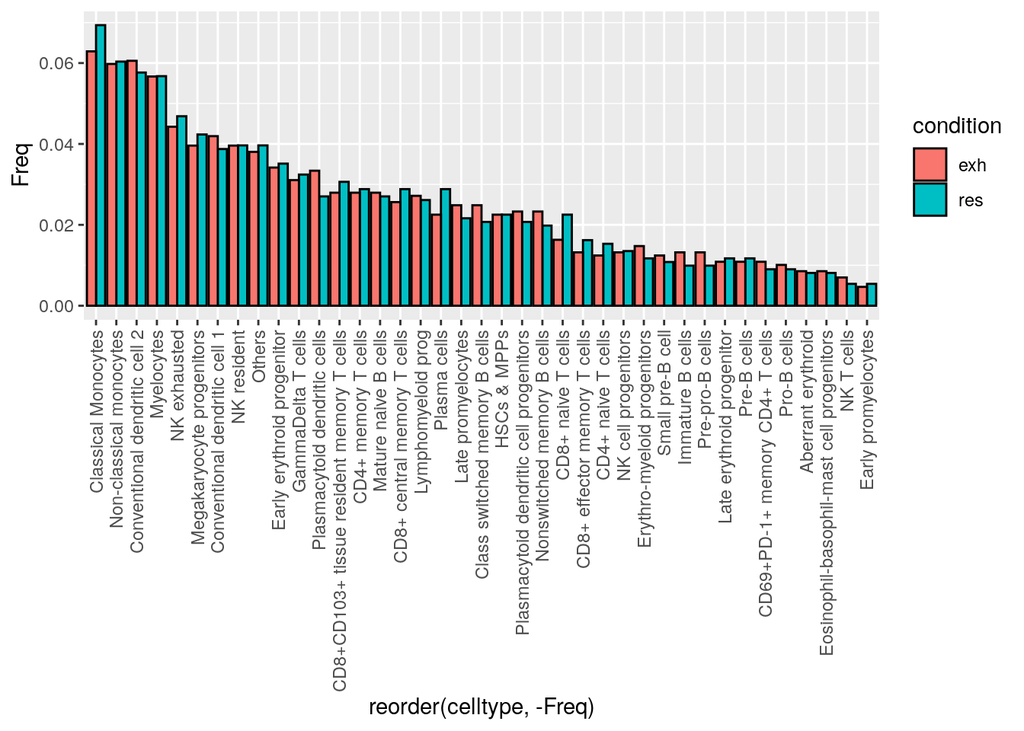

```r
source_dodge <- ggplot(source, aes(x=reorder(celltype,-Freq), y=Freq, fill=condition)) +
geom_bar(stat="identity", color="black", position=position_dodge())+
  theme(axis.text.x = element_text(angle = 90, vjust = 0.5, hjust=1))

source_dodge
```

The proportions of cell types communicating with NK cells are similar between the conditions

## Number of interacting ligands

Now let’s check the receptors that receive most interaction from other cell types (top 10 for each NK cell for the sake of readability)

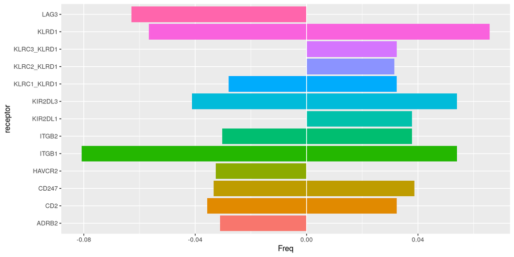

```r
exh_source <- as.data.frame(table(exh$receptor.complex)/sum(table(exh$receptor.complex))) %>%
  arrange(desc(Freq)) %>%
  rename(receptor = "Var1") %>%
  mutate(condition="exh")
res_source <- as.data.frame(table(res$receptor.complex)/sum(table(res$receptor.complex))) %>%
  arrange(desc(Freq)) %>%
  rename(receptor = "Var1") %>%
  mutate(condition="res")

source <- rbind(res_source[1:10,],exh_source[1:10,])

source_plot <- source %>%
  mutate(
    Freq = ifelse(condition=="exh", Freq*(-1),
                        Freq*1))%>%
    ggplot(aes(x = receptor,y = Freq, fill=receptor)) +
    geom_bar(stat = "identity") +
    coord_flip() +
    geom_hline(yintercept = 0, color="white")+

  theme(legend.position = "none")

source_plot
```

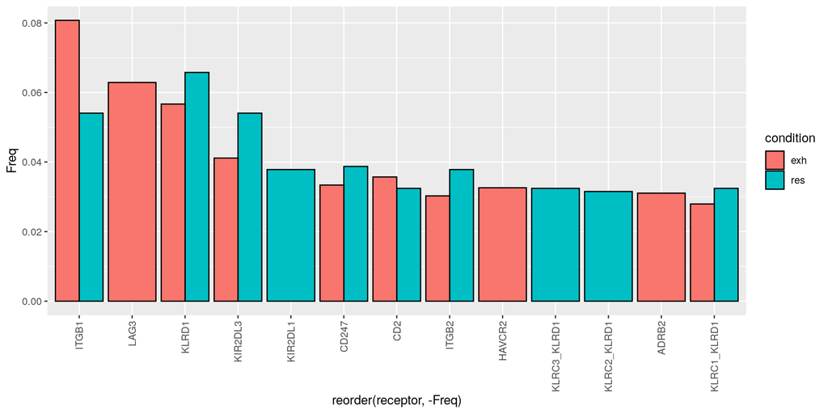

```r
source_dodge <- ggplot(source, aes(x=reorder(receptor,-Freq), y=Freq, fill=condition)) +
geom_bar(stat="identity", color="black", position=position_dodge())+
  theme(axis.text.x = element_text(angle = 90, vjust = 0.5, hjust=1))

source_dodge
```

- [KLRD1/CD94](https://www.jci.org/articles/view/123955) Immune checkpoint receptor
- KLRC1/NKG2A Inhibitory, KRLC2/NKG2C Activating, KLRC3 miss info
- ITGB1/2 Integrins
- HAVCR2/TIM3 Immune checkpoint receptor -CD247 Activating
- [CD2](https://pubmed.ncbi.nlm.nih.gov/16323413/) Activating
- [ADRB2](https://pubmed.ncbi.nlm.nih.gov/32045471/)Cell-intrinsic adrenergic signaling controls the adaptive NK cell response to viral infection

## Immune checkpoint receptors:

Now have a look on the immune checkpoint receptors in exhausted cells:

```r
ICR = c("KLRB1|KLRC1|KLRD1|KIR2DL1|KIR2DL3|KIR3DL1|KIR3DL2|KLRG1|KIR2DL4|TIGIT|LAG3|HAVCR2|BTLA|PDCD1|LILRB1|LILRB2|LILRB3|LILRB4|LILRB5|SIGLEC7|LAIR1|CEACAM1|PILRA|CD300A|CD96")

exh_ICR <- exh %>%
  filter(grepl(ICR,receptor.complex)) %>%
  filter(!grepl("KLRC2|KLRC3", receptor.complex))

res_ICR <- res %>%
  filter(grepl(ICR,receptor.complex)) %>%
  filter(!grepl("KLRC2|KLRC3", receptor.complex))


cat("Exhausted cells:\nTotal number of ICR interactions: ",dim(exh_ICR)[1],"\nUnique Ligands: ",length(unique(sort(exh_ICR$ligand.complex))),"\nUnique Receptors: ",length(unique(sort(exh_ICR$receptor.complex))),"\n\n")
```

```
## Exhausted cells:
## Total number of ICR interactions:  347
## Unique Ligands:  23
## Unique Receptors:  11
```

```r
cat("Resident cells:\nTotal number of interactions: ",dim(res_ICR)[1],"\nUnique Ligands: ",length(unique(sort(res_ICR$ligand.complex))),"\nUnique Receptors: ",length(unique(sort(res_ICR$receptor.complex))))
```

```
## Resident cells:
## Total number of interactions:  297
## Unique Ligands:  12
## Unique Receptors:  10
```

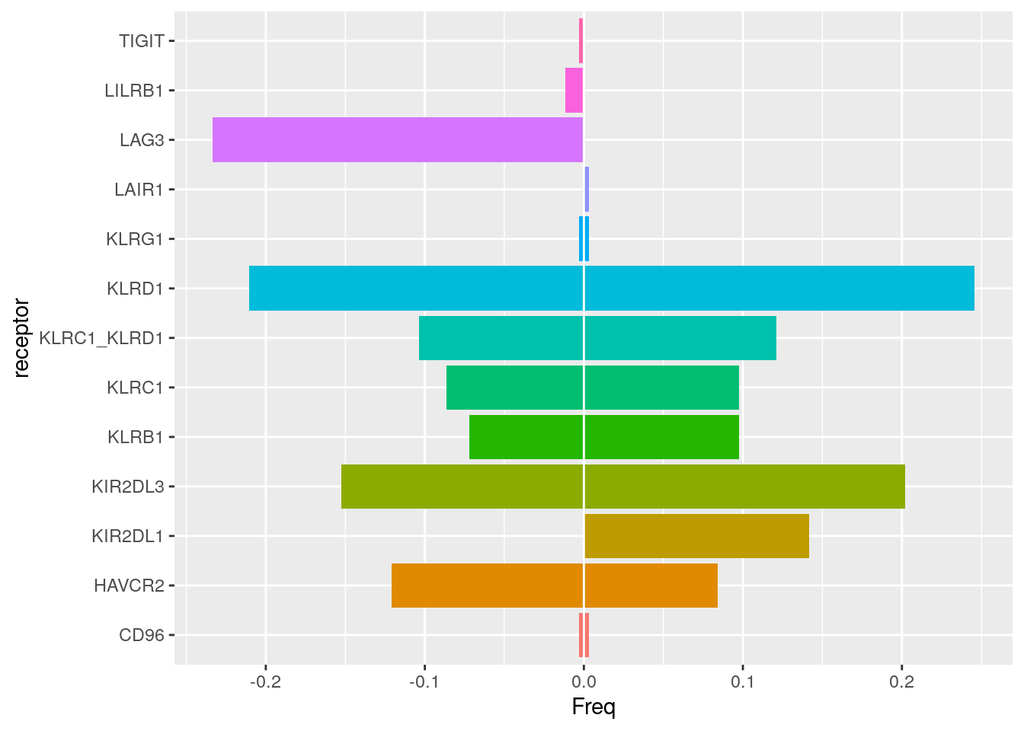

```r
exh_source <- as.data.frame(table(exh_ICR$receptor.complex)/sum(table(exh_ICR$receptor.complex))) %>%
  arrange(desc(Freq)) %>%
  rename(receptor = "Var1") %>%
  mutate(condition="exh")
res_source <- as.data.frame(table(res_ICR$receptor.complex)/sum(table(res_ICR$receptor.complex))) %>%
  arrange(desc(Freq)) %>%
  rename(receptor = "Var1") %>%
  mutate(condition="res")

source <- rbind(res_source,exh_source)

source_plot <- source %>%
  mutate(
    Freq = ifelse(condition=="exh", Freq*(-1),
                        Freq*1))%>%
    ggplot(aes(x = receptor,y = Freq, fill=receptor)) +
    geom_bar(stat = "identity") +
    coord_flip() +
    geom_hline(yintercept = 0, color="white")+

  theme(legend.position = "none")

source_plot
```

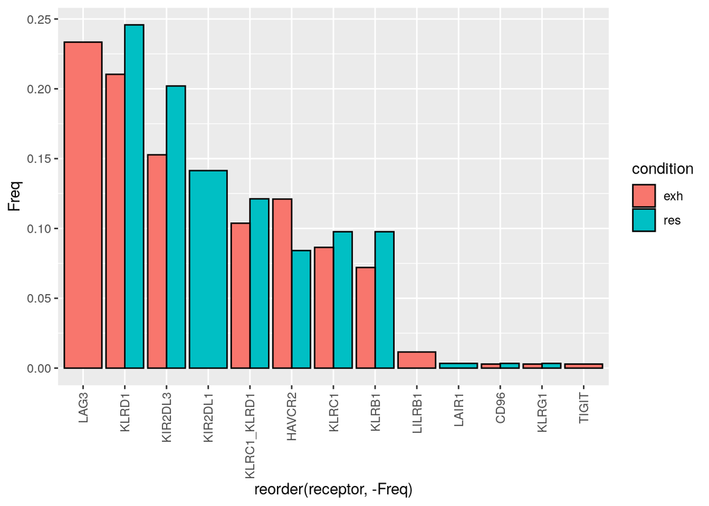

```r
source_dodge <- ggplot(source, aes(x=reorder(receptor,-Freq), y=Freq, fill=condition)) +
geom_bar(stat="identity", color="black", position=position_dodge())+
  theme(axis.text.x = element_text(angle = 90, vjust = 0.5, hjust=1))

source_dodge
```

### Exhausted cells

- LAG3 is the receptor that receive the highest number of interaction
- TIGIT, LILRB1, and LAG3 are present only in exhausted cells, the first two with small nuber of interactions
- HAVCR2/TIM3 is receive more interactions in exhausted than resident NK cells

# Conclusions

# Future steps

- Incorporate the selected receptors in nichenet to build a regulatory network
- Compare the interactomes of MM and healthy samples (to be run)